# Health Data Notebook

> by Jonathan Ferrari, for Data 198 Spring 2022

## Introduction

In this notebook, I will explore and do some basic data analysis of a filed called `health.csv`. This file contains some data about my 2021 year in the context of my health. Let's dive into it!

## Imports

First, we need to make some basic imports so we can look at this data!

```python
import pandas as pd
import numpy as np
import plotly
import plotly.express as px
import matplotlib
import matplotlib.pyplot as plt
from IPython.display import display
plt.style.use("fivethirtyeight")
```

## The Data

Let's load the data and look at it as a `pd.DataFrame`

```python
health = pd.read_csv("/Users/jonathanferrari/Downloads/Spring 2022/Data Science 198 - Instructional Support Seminar/Data198-SP22/data/Health.csv")
display(health)
display(health.describe().iloc[:, 1:3])
```

|  | date | month | day | calories | miles |
| --- | --- | --- | --- | --- | --- |
| 0 | 1 | Jan | Friday | 692.881761 | 3.722718 |
| 1 | 2 | Jan | Saturday | 536.691408 | 1.896977 |
| 2 | 3 | Jan | Sunday | 276.351000 | 1.696723 |
| 3 | 4 | Jan | Monday | 270.923147 | 1.502654 |
| 4 | 5 | Jan | Tuesday | 397.484041 | 2.173992 |
| ... | ... | ... | ... | ... | ... |
| 360 | 27 | Dec | Monday | 0.164000 | 1.537434 |
| 361 | 28 | Dec | Tuesday | 372.944000 | 1.694043 |
| 362 | 29 | Dec | Wednesday | 1043.590545 | 5.737930 |
| 363 | 30 | Dec | Thursday | 542.194505 | 2.420097 |
| 364 | 31 | Dec | Friday | 615.976073 | 2.928637 |

365 rows × 5 columns

|  | calories | miles |
| --- | --- | --- |
| count | 365.000000 | 365.000000 |
| mean | 610.901924 | 3.397468 |
| std | 247.724318 | 1.892034 |
| min | 0.164000 | 1.020860 |
| 25% | 434.875116 | 2.104381 |
| 50% | 581.203988 | 2.787204 |
| 75% | 751.915536 | 4.196303 |
| max | 1625.688000 | 10.193427 |

## Data Cleaning

I didn't wear my watch some days, but my phone tracked my miles, so I'll filter out the days where my watch wasn't on so our analysis will be more accurate.

```python
health = health.query("calories > 100")
```

## Graphs, Graphs, and more Graphs!

Now lets graph this and do some simple linear regression!

### `matplotlib` Plots

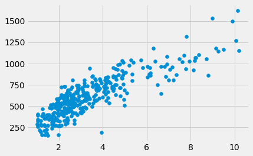

```python
plt.scatter(data = health, x = 'miles', y = 'calories');
```

### `plotly` Plots

To be frank, I'm not a fan of `matplotlib`, the visualizations are boring! Instead let's look at it using an interactive (and user-friendly) library named `plotly`

```python
(slope, intercept), r = (np.round(np.polyfit(health['miles'], health['calories'], 1), 2),
                        np.round(np.corrcoef(health['miles'], health['calories'])[0][1], 4))
px.scatter(data_frame = health, x = 'miles', y = 'calories' , range_y = (0, 1650),
           trendline = 'ols', title=f"Miles vs. Calories\nTrednline: R^2: {r} Calories = {slope}*miles + {intercept}")
```

[interactive chart not shown]

## Data Visualization Explorations

Lastly, lets get a little fancy and look at the data by `month` or even how far into the year we were! Ya know what, lets do them all!

```python
def my_year(colorize):
    rep = 'index'
    if type(colorize) == str:
        rep = colorize
    display(px.scatter(data_frame = health, x = 'miles', y = 'calories' , range_y = (0, 1650),
               title=f"Miles vs. Calories [Colored by {rep}]\nTrednline: R^2: {r} Calories = {slope}*miles + {intercept}",
              color = colorize))
color_cols = [health.index, 'date', 'month', 'day', 'calories', 'miles']
```

```python
for group in color_cols:
    my_year(group)
```

[interactive chart not shown]

## Conclusion

### Thats all for now!

> Thanks for reading and I hope you enjoyed this demo!